# Risk Factor Analysis

## Outcome Variable

**Outcome Variable:** whz

## Predictor Variables

**Intervention Variable:** perdiar6

**Adjustment Set:**

- arm
- sex
- W_mage
- meducyrs
- feducyrs
- hhwealth_quart
- hfoodsec
- W_mhtcm
- W_mwtkg
- W_mbmi
- W_birthwt
- W_birthlen
- W_nrooms
- month
- brthmon
- impfloor
- impsan
- safeh20
- delta_W_mage
- delta_meducyrs
- delta_feducyrs
- delta_hhwealth_quart
- delta_hfoodsec
- delta_W_mhtcm
- delta_W_mwtkg
- delta_W_mbmi
- delta_W_birthwt
- delta_W_birthlen
- delta_W_nrooms
- delta_month
- delta_brthmon
- delta_impfloor
- delta_impsan
- delta_safeh20

## Stratifying Variables

The analysis was stratified on these variable(s):

- agecat
- studyid
- country

## Data Summary

| agecat | studyid | country | perdiar6 | n_cell | n |
| --- | --- | --- | --- | --- | --- |
| Birth | CMIN | BANGLADESH | 0% | 10 | 19 |
| Birth | CMIN | BANGLADESH | (0%, 5%] | 3 | 19 |
| Birth | CMIN | BANGLADESH | >5% | 6 | 19 |
| Birth | CONTENT | PERU | 0% | 0 | 2 |
| Birth | CONTENT | PERU | (0%, 5%] | 1 | 2 |
| Birth | CONTENT | PERU | >5% | 1 | 2 |
| Birth | EE | PAKISTAN | 0% | 164 | 177 |
| Birth | EE | PAKISTAN | (0%, 5%] | 11 | 177 |
| Birth | EE | PAKISTAN | >5% | 2 | 177 |
| Birth | MAL-ED | BANGLADESH | 0% | 65 | 215 |
| Birth | MAL-ED | BANGLADESH | (0%, 5%] | 86 | 215 |
| Birth | MAL-ED | BANGLADESH | >5% | 64 | 215 |
| Birth | MAL-ED | BRAZIL | 0% | 54 | 62 |
| Birth | MAL-ED | BRAZIL | (0%, 5%] | 6 | 62 |
| Birth | MAL-ED | BRAZIL | >5% | 2 | 62 |
| Birth | MAL-ED | INDIA | 0% | 11 | 45 |
| Birth | MAL-ED | INDIA | (0%, 5%] | 23 | 45 |
| Birth | MAL-ED | INDIA | >5% | 11 | 45 |
| Birth | MAL-ED | NEPAL | 0% | 8 | 26 |
| Birth | MAL-ED | NEPAL | (0%, 5%] | 10 | 26 |
| Birth | MAL-ED | NEPAL | >5% | 8 | 26 |
| Birth | MAL-ED | PERU | 0% | 67 | 228 |
| Birth | MAL-ED | PERU | (0%, 5%] | 69 | 228 |
| Birth | MAL-ED | PERU | >5% | 92 | 228 |
| Birth | MAL-ED | SOUTH AFRICA | 0% | 85 | 112 |
| Birth | MAL-ED | SOUTH AFRICA | (0%, 5%] | 23 | 112 |
| Birth | MAL-ED | SOUTH AFRICA | >5% | 4 | 112 |
| Birth | MAL-ED | TANZANIA, UNITED REPUBLIC OF | 0% | 51 | 115 |
| Birth | MAL-ED | TANZANIA, UNITED REPUBLIC OF | (0%, 5%] | 44 | 115 |
| Birth | MAL-ED | TANZANIA, UNITED REPUBLIC OF | >5% | 20 | 115 |

[output cut: 87 more lines]

The following strata were considered:

- agecat: 24 months, studyid: CMIN, country: BANGLADESH
- agecat: 24 months, studyid: CONTENT, country: PERU
- agecat: 24 months, studyid: EE, country: PAKISTAN
- agecat: 24 months, studyid: MAL-ED, country: BANGLADESH
- agecat: 24 months, studyid: MAL-ED, country: BRAZIL
- agecat: 24 months, studyid: MAL-ED, country: INDIA
- agecat: 24 months, studyid: MAL-ED, country: NEPAL
- agecat: 24 months, studyid: MAL-ED, country: PERU
- agecat: 24 months, studyid: MAL-ED, country: SOUTH AFRICA
- agecat: 24 months, studyid: MAL-ED, country: TANZANIA, UNITED REPUBLIC OF
- agecat: 24 months, studyid: NIH-Birth, country: BANGLADESH
- agecat: 24 months, studyid: NIH-Crypto, country: BANGLADESH
- agecat: 24 months, studyid: PROVIDE, country: BANGLADESH
- agecat: 6 months, studyid: CMIN, country: BANGLADESH
- agecat: 6 months, studyid: CONTENT, country: PERU
- agecat: 6 months, studyid: EE, country: PAKISTAN
- agecat: 6 months, studyid: MAL-ED, country: BANGLADESH
- agecat: 6 months, studyid: MAL-ED, country: BRAZIL
- agecat: 6 months, studyid: MAL-ED, country: INDIA
- agecat: 6 months, studyid: MAL-ED, country: NEPAL
- agecat: 6 months, studyid: MAL-ED, country: PERU
- agecat: 6 months, studyid: MAL-ED, country: SOUTH AFRICA
- agecat: 6 months, studyid: MAL-ED, country: TANZANIA, UNITED REPUBLIC OF
- agecat: 6 months, studyid: NIH-Birth, country: BANGLADESH
- agecat: 6 months, studyid: NIH-Crypto, country: BANGLADESH
- agecat: 6 months, studyid: PROVIDE, country: BANGLADESH
- agecat: Birth, studyid: CMIN, country: BANGLADESH
- agecat: Birth, studyid: CONTENT, country: PERU
- agecat: Birth, studyid: EE, country: PAKISTAN
- agecat: Birth, studyid: MAL-ED, country: BANGLADESH
- agecat: Birth, studyid: MAL-ED, country: BRAZIL
- agecat: Birth, studyid: MAL-ED, country: INDIA
- agecat: Birth, studyid: MAL-ED, country: NEPAL
- agecat: Birth, studyid: MAL-ED, country: PERU
- agecat: Birth, studyid: MAL-ED, country: SOUTH AFRICA
- agecat: Birth, studyid: MAL-ED, country: TANZANIA, UNITED REPUBLIC OF
- agecat: Birth, studyid: NIH-Birth, country: BANGLADESH
- agecat: Birth, studyid: NIH-Crypto, country: BANGLADESH
- agecat: Birth, studyid: PROVIDE, country: BANGLADESH

### Dropped Strata

Some strata were dropped due to rare outcomes:

- agecat: Birth, studyid: CMIN, country: BANGLADESH
- agecat: Birth, studyid: CONTENT, country: PERU
- agecat: Birth, studyid: EE, country: PAKISTAN
- agecat: Birth, studyid: MAL-ED, country: BRAZIL
- agecat: Birth, studyid: MAL-ED, country: SOUTH AFRICA
- agecat: 6 months, studyid: EE, country: PAKISTAN
- agecat: 6 months, studyid: MAL-ED, country: BRAZIL
- agecat: 24 months, studyid: EE, country: PAKISTAN
- agecat: 24 months, studyid: MAL-ED, country: BRAZIL

## Methods Detail

We’re interested in the causal parameters $E[Y_a]$ for all values of $a \in \mathcal{A}$. These parameters represent the mean outcome if, possibly contrary to fact, we intervened to set all units to have $A=a$. Under the randomization and positivity assumptions, these are identified by the statistical parameters $\psi_a=E_W[E_{Y|A,W}(Y|A=a,W)]$. In addition, we’re interested in the mean of $Y$, $E[Y]$ under no intervention (the observed mean). We will estimate these parameters by using SuperLearner to fit the relevant likelihood factors – $E_{Y|A,W}(Y|A=a,W)$ and $p(A=a|W)$, and then updating our likelihood fit using a joint TMLE.

For unadjusted analyses ($W=\{\}$), initial likelihoods were estimated using Lrnr_glm to estimate the simple $E(Y|A)$ and Lrnr_mean to estimate $p(A)$. For adjusted analyses, a small library containing Lrnr_glmnet, Lrnr_xgboost, and Lrnr_mean was used.

Having estimated these parameters, we will then use the delta method to estimate relative risks and attributable risks relative to a prespecified baseline level of $A$.

# Results Detail

## Results Plots

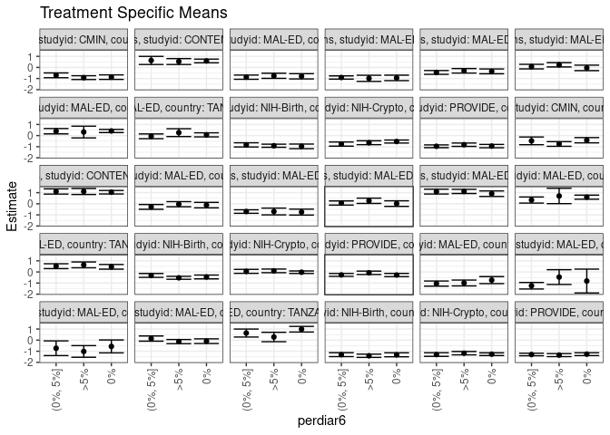

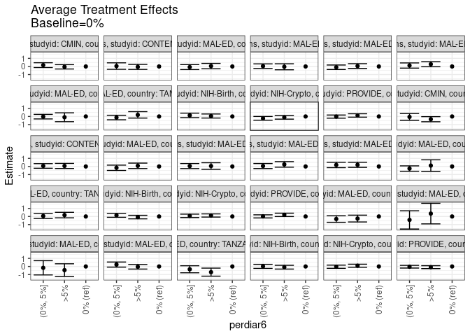

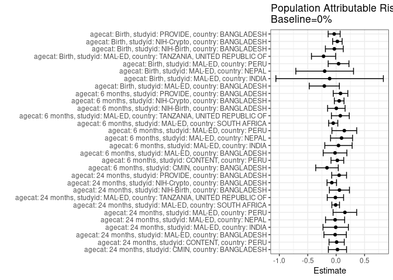

## Results Table

### Parameter: TSM

| agecat | studyid | country | intervention_level | baseline_level | estimate | ci_lower | ci_upper |
| --- | --- | --- | --- | --- | --- | --- | --- |
| Birth | MAL-ED | BANGLADESH | 0% | NA | -0.7337844 | -1.0504225 | -0.4171464 |
| Birth | MAL-ED | BANGLADESH | (0%, 5%] | NA | -1.0461239 | -1.2767010 | -0.8155469 |
| Birth | MAL-ED | BANGLADESH | >5% | NA | -0.9921020 | -1.2556309 | -0.7285732 |
| Birth | MAL-ED | INDIA | 0% | NA | -0.8173212 | -1.8879958 | 0.2533535 |
| Birth | MAL-ED | INDIA | (0%, 5%] | NA | -1.2420022 | -1.5353445 | -0.9486600 |
| Birth | MAL-ED | INDIA | >5% | NA | -0.4627391 | -1.1281185 | 0.2026404 |
| Birth | MAL-ED | NEPAL | 0% | NA | -0.5662500 | -1.1479485 | 0.0154485 |
| Birth | MAL-ED | NEPAL | (0%, 5%] | NA | -0.7310000 | -1.3926378 | -0.0693622 |
| Birth | MAL-ED | NEPAL | >5% | NA | -1.0175000 | -1.5408661 | -0.4941339 |
| Birth | MAL-ED | PERU | 0% | NA | -0.0943534 | -0.3040050 | 0.1152982 |
| Birth | MAL-ED | PERU | (0%, 5%] | NA | 0.1401236 | -0.0935514 | 0.3737987 |
| Birth | MAL-ED | PERU | >5% | NA | -0.1319614 | -0.3204632 | 0.0565404 |
| Birth | MAL-ED | TANZANIA, UNITED REPUBLIC OF | 0% | NA | 0.9840087 | 0.7308741 | 1.2371432 |
| Birth | MAL-ED | TANZANIA, UNITED REPUBLIC OF | (0%, 5%] | NA | 0.6383624 | 0.2802576 | 0.9964673 |
| Birth | MAL-ED | TANZANIA, UNITED REPUBLIC OF | >5% | NA | 0.2834350 | -0.1395156 | 0.7063856 |
| Birth | NIH-Birth | BANGLADESH | 0% | NA | -1.3206371 | -1.4996817 | -1.1415924 |
| Birth | NIH-Birth | BANGLADESH | (0%, 5%] | NA | -1.3074428 | -1.4829924 | -1.1318932 |
| Birth | NIH-Birth | BANGLADESH | >5% | NA | -1.4075665 | -1.5532159 | -1.2619172 |
| Birth | NIH-Crypto | BANGLADESH | 0% | NA | -1.2659296 | -1.3890054 | -1.1428539 |
| Birth | NIH-Crypto | BANGLADESH | (0%, 5%] | NA | -1.2969965 | -1.4591167 | -1.1348762 |
| Birth | NIH-Crypto | BANGLADESH | >5% | NA | -1.1748583 | -1.3256336 | -1.0240830 |
| Birth | PROVIDE | BANGLADESH | 0% | NA | -1.2631997 | -1.3921448 | -1.1342546 |
| Birth | PROVIDE | BANGLADESH | (0%, 5%] | NA | -1.2935349 | -1.4071085 | -1.1799613 |
| Birth | PROVIDE | BANGLADESH | >5% | NA | -1.3461648 | -1.4822358 | -1.2100938 |
| 6 months | CMIN | BANGLADESH | 0% | NA | -0.4167748 | -0.6523450 | -0.1812047 |
| 6 months | CMIN | BANGLADESH | (0%, 5%] | NA | -0.4727760 | -0.8203838 | -0.1251683 |
| 6 months | CMIN | BANGLADESH | >5% | NA | -0.7542335 | -0.9643238 | -0.5441432 |
| 6 months | CONTENT | PERU | 0% | NA | 1.0430836 | 0.8854327 | 1.2007344 |
| 6 months | CONTENT | PERU | (0%, 5%] | NA | 1.1077645 | 0.8726990 | 1.3428300 |
| 6 months | CONTENT | PERU | >5% | NA | 1.1067303 | 0.8373167 | 1.3761438 |

[output cut: 60 more lines]

### Parameter: E(Y)

| agecat | studyid | country | intervention_level | baseline_level | estimate | ci_lower | ci_upper |
| --- | --- | --- | --- | --- | --- | --- | --- |
| Birth | MAL-ED | BANGLADESH | NA | NA | -0.9418605 | -1.0869834 | -0.7967375 |
| Birth | MAL-ED | INDIA | NA | NA | -0.9324444 | -1.2067907 | -0.6580982 |
| Birth | MAL-ED | NEPAL | NA | NA | -0.7684615 | -1.1257770 | -0.4111460 |
| Birth | MAL-ED | PERU | NA | NA | -0.0520175 | -0.1725298 | 0.0684947 |
| Birth | MAL-ED | TANZANIA, UNITED REPUBLIC OF | NA | NA | 0.7624348 | 0.5710709 | 0.9537986 |
| Birth | NIH-Birth | BANGLADESH | NA | NA | -1.3525437 | -1.4473932 | -1.2576942 |
| Birth | NIH-Crypto | BANGLADESH | NA | NA | -1.2441513 | -1.3281130 | -1.1601897 |
| Birth | PROVIDE | BANGLADESH | NA | NA | -1.2984586 | -1.3752758 | -1.2216415 |
| 6 months | CMIN | BANGLADESH | NA | NA | -0.5780453 | -0.7226627 | -0.4334279 |
| 6 months | CONTENT | PERU | NA | NA | 1.0644279 | 0.9468682 | 1.1819876 |
| 6 months | MAL-ED | BANGLADESH | NA | NA | -0.1376763 | -0.2664642 | -0.0088885 |
| 6 months | MAL-ED | INDIA | NA | NA | -0.7079979 | -0.8344175 | -0.5815783 |
| 6 months | MAL-ED | NEPAL | NA | NA | 0.1104308 | -0.0208643 | 0.2417259 |
| 6 months | MAL-ED | PERU | NA | NA | 1.0528816 | 0.9313005 | 1.1744626 |
| 6 months | MAL-ED | SOUTH AFRICA | NA | NA | 0.5421785 | 0.3900443 | 0.6943126 |
| 6 months | MAL-ED | TANZANIA, UNITED REPUBLIC OF | NA | NA | 0.5362213 | 0.4049390 | 0.6675036 |
| 6 months | NIH-Birth | BANGLADESH | NA | NA | -0.4474038 | -0.5378167 | -0.3569909 |
| 6 months | NIH-Crypto | BANGLADESH | NA | NA | 0.0297622 | -0.0491685 | 0.1086930 |
| 6 months | PROVIDE | BANGLADESH | NA | NA | -0.1990907 | -0.2817968 | -0.1163845 |
| 24 months | CMIN | BANGLADESH | NA | NA | -0.8535391 | -0.9644236 | -0.7426546 |
| 24 months | CONTENT | PERU | NA | NA | 0.5902439 | 0.4560143 | 0.7244735 |
| 24 months | MAL-ED | BANGLADESH | NA | NA | -0.8192925 | -0.9412667 | -0.6973182 |
| 24 months | MAL-ED | INDIA | NA | NA | -0.9516520 | -1.0670654 | -0.8362385 |
| 24 months | MAL-ED | NEPAL | NA | NA | -0.3749123 | -0.4886073 | -0.2612173 |
| 24 months | MAL-ED | PERU | NA | NA | 0.1111982 | -0.0118399 | 0.2342362 |
| 24 months | MAL-ED | SOUTH AFRICA | NA | NA | 0.4090301 | 0.2879441 | 0.5301161 |
| 24 months | MAL-ED | TANZANIA, UNITED REPUBLIC OF | NA | NA | 0.0547975 | -0.0703378 | 0.1799328 |
| 24 months | NIH-Birth | BANGLADESH | NA | NA | -0.9115790 | -1.0095022 | -0.8136559 |
| 24 months | NIH-Crypto | BANGLADESH | NA | NA | -0.6103502 | -0.7050157 | -0.5156847 |
| 24 months | PROVIDE | BANGLADESH | NA | NA | -0.8928670 | -0.9755153 | -0.8102187 |

### Parameter: ATE

| agecat | studyid | country | intervention_level | baseline_level | estimate | ci_lower | ci_upper |
| --- | --- | --- | --- | --- | --- | --- | --- |
| Birth | MAL-ED | BANGLADESH | 0% | 0% | 0.0000000 | 0.0000000 | 0.0000000 |
| Birth | MAL-ED | BANGLADESH | (0%, 5%] | 0% | -0.3123395 | -0.7194970 | 0.0948179 |
| Birth | MAL-ED | BANGLADESH | >5% | 0% | -0.2583176 | -0.6778308 | 0.1611955 |
| Birth | MAL-ED | INDIA | 0% | 0% | 0.0000000 | 0.0000000 | 0.0000000 |
| Birth | MAL-ED | INDIA | (0%, 5%] | 0% | -0.4246811 | -1.5525356 | 0.7031735 |
| Birth | MAL-ED | INDIA | >5% | 0% | 0.3545821 | -0.9168212 | 1.6259854 |
| Birth | MAL-ED | NEPAL | 0% | 0% | 0.0000000 | 0.0000000 | 0.0000000 |
| Birth | MAL-ED | NEPAL | (0%, 5%] | 0% | -0.1647500 | -1.0457368 | 0.7162368 |
| Birth | MAL-ED | NEPAL | >5% | 0% | -0.4512500 | -1.2337366 | 0.3312366 |
| Birth | MAL-ED | PERU | 0% | 0% | 0.0000000 | 0.0000000 | 0.0000000 |
| Birth | MAL-ED | PERU | (0%, 5%] | 0% | 0.2344770 | -0.0799372 | 0.5488912 |
| Birth | MAL-ED | PERU | >5% | 0% | -0.0376080 | -0.3199682 | 0.2447522 |
| Birth | MAL-ED | TANZANIA, UNITED REPUBLIC OF | 0% | 0% | 0.0000000 | 0.0000000 | 0.0000000 |
| Birth | MAL-ED | TANZANIA, UNITED REPUBLIC OF | (0%, 5%] | 0% | -0.3456462 | -0.7802104 | 0.0889180 |
| Birth | MAL-ED | TANZANIA, UNITED REPUBLIC OF | >5% | 0% | -0.7005736 | -1.1955194 | -0.2056279 |
| Birth | NIH-Birth | BANGLADESH | 0% | 0% | 0.0000000 | 0.0000000 | 0.0000000 |
| Birth | NIH-Birth | BANGLADESH | (0%, 5%] | 0% | 0.0131943 | -0.2373013 | 0.2636898 |
| Birth | NIH-Birth | BANGLADESH | >5% | 0% | -0.0869295 | -0.3181765 | 0.1443175 |
| Birth | NIH-Crypto | BANGLADESH | 0% | 0% | 0.0000000 | 0.0000000 | 0.0000000 |
| Birth | NIH-Crypto | BANGLADESH | (0%, 5%] | 0% | -0.0310668 | -0.2299565 | 0.1678228 |
| Birth | NIH-Crypto | BANGLADESH | >5% | 0% | 0.0910714 | -0.0983720 | 0.2805147 |
| Birth | PROVIDE | BANGLADESH | 0% | 0% | 0.0000000 | 0.0000000 | 0.0000000 |
| Birth | PROVIDE | BANGLADESH | (0%, 5%] | 0% | -0.0303352 | -0.1961795 | 0.1355090 |
| Birth | PROVIDE | BANGLADESH | >5% | 0% | -0.0829651 | -0.2648997 | 0.0989694 |
| 6 months | CMIN | BANGLADESH | 0% | 0% | 0.0000000 | 0.0000000 | 0.0000000 |
| 6 months | CMIN | BANGLADESH | (0%, 5%] | 0% | -0.0560012 | -0.4750686 | 0.3630662 |
| 6 months | CMIN | BANGLADESH | >5% | 0% | -0.3374587 | -0.6536620 | -0.0212554 |
| 6 months | CONTENT | PERU | 0% | 0% | 0.0000000 | 0.0000000 | 0.0000000 |
| 6 months | CONTENT | PERU | (0%, 5%] | 0% | 0.0646809 | -0.2192452 | 0.3486071 |
| 6 months | CONTENT | PERU | >5% | 0% | 0.0636467 | -0.2498605 | 0.3771539 |

[output cut: 60 more lines]

### Parameter: PAR

| agecat | studyid | country | intervention_level | baseline_level | estimate | ci_lower | ci_upper |
| --- | --- | --- | --- | --- | --- | --- | --- |
| Birth | MAL-ED | BANGLADESH | 0% | NA | -0.2080760 | -0.4728887 | 0.0567366 |
| Birth | MAL-ED | INDIA | 0% | NA | -0.1151233 | -1.0607102 | 0.8304637 |
| Birth | MAL-ED | NEPAL | 0% | NA | -0.2022115 | -0.7099692 | 0.3055462 |
| Birth | MAL-ED | PERU | 0% | NA | 0.0423358 | -0.1400603 | 0.2247320 |
| Birth | MAL-ED | TANZANIA, UNITED REPUBLIC OF | 0% | NA | -0.2215739 | -0.4344069 | -0.0087408 |
| Birth | NIH-Birth | BANGLADESH | 0% | NA | -0.0319067 | -0.1890714 | 0.1252580 |
| Birth | NIH-Crypto | BANGLADESH | 0% | NA | 0.0217783 | -0.0619546 | 0.1055112 |
| Birth | PROVIDE | BANGLADESH | 0% | NA | -0.0352590 | -0.1405968 | 0.0700788 |
| 6 months | CMIN | BANGLADESH | 0% | NA | -0.1612705 | -0.3597403 | 0.0371994 |
| 6 months | CONTENT | PERU | 0% | NA | 0.0213443 | -0.0905552 | 0.1332438 |
| 6 months | MAL-ED | BANGLADESH | 0% | NA | -0.0198843 | -0.2279630 | 0.1881943 |
| 6 months | MAL-ED | INDIA | 0% | NA | 0.0409156 | -0.1998031 | 0.2816342 |
| 6 months | MAL-ED | NEPAL | 0% | NA | 0.0948633 | -0.0988841 | 0.2886107 |
| 6 months | MAL-ED | PERU | 0% | NA | 0.1436318 | -0.0746527 | 0.3619162 |
| 6 months | MAL-ED | SOUTH AFRICA | 0% | NA | -0.0518040 | -0.1322455 | 0.0286376 |
| 6 months | MAL-ED | TANZANIA, UNITED REPUBLIC OF | 0% | NA | 0.0735980 | -0.0835554 | 0.2307515 |
| 6 months | NIH-Birth | BANGLADESH | 0% | NA | 0.0033486 | -0.1506956 | 0.1573927 |
| 6 months | NIH-Crypto | BANGLADESH | 0% | NA | 0.0532584 | -0.0317992 | 0.1383161 |
| 6 months | PROVIDE | BANGLADESH | 0% | NA | 0.0768720 | -0.0511713 | 0.2049153 |
| 24 months | CMIN | BANGLADESH | 0% | NA | 0.0229588 | -0.1369461 | 0.1828638 |
| 24 months | CONTENT | PERU | 0% | NA | 0.0084804 | -0.1253225 | 0.1422833 |
| 24 months | MAL-ED | BANGLADESH | 0% | NA | -0.0182530 | -0.2155207 | 0.1790148 |
| 24 months | MAL-ED | INDIA | 0% | NA | -0.0078269 | -0.2309013 | 0.2152475 |
| 24 months | MAL-ED | NEPAL | 0% | NA | -0.0187142 | -0.1869274 | 0.1494990 |
| 24 months | MAL-ED | PERU | 0% | NA | 0.1535589 | -0.0540787 | 0.3611965 |
| 24 months | MAL-ED | SOUTH AFRICA | 0% | NA | -0.0086347 | -0.0759944 | 0.0587251 |
| 24 months | MAL-ED | TANZANIA, UNITED REPUBLIC OF | 0% | NA | -0.0131871 | -0.1570292 | 0.1306550 |
| 24 months | NIH-Birth | BANGLADESH | 0% | NA | 0.0574962 | -0.1190013 | 0.2339936 |
| 24 months | NIH-Crypto | BANGLADESH | 0% | NA | -0.0769532 | -0.1604959 | 0.0065894 |
| 24 months | PROVIDE | BANGLADESH | 0% | NA | 0.0520383 | -0.0785730 | 0.1826496 |